# Assignment

#### **Binary classification (prediction).**

###### *Mikhail Galkin, 2018.may*

#### Loading data and doing first view on it.

```r
## Load data
DT <- read.csv(file = "T:\\Documents\\RProjects\\Assignment\\Assignment_Data.csv",
               header = TRUE, sep = ';', stringsAsFactors = FALSE,
               na.strings = c('NULL', 'NA', 'N/A','', '?'))
class(DT)  # view class
```

```
## [1] "data.frame"
```

```r
DT <- as.data.table(DT)  # convert to data.table

## View summary info
str(DT)  # view structure & ...
```

```
## Classes 'data.table' and 'data.frame':   2572 obs. of  55 variables:
##  $ country_id              : int  21 21 21 21 21 21 21 21 21 21 ...
##  $ application_id          : int  24176 24185 24215 24220 24255 24260 24280 24314 24349 24368 ...
##  $ product_id              : int  21210001 21210001 21210001 21210001 21210001 21210001 21210001 21210001 21210001 21210001 ...
##  $ Variable_1              : int  35 30 30 30 30 40 33 45 45 45 ...
##  $ Variable_2              : int  1 1 1 1 2 2 1 1 1 1 ...
##  $ Variable_3              : int  1 1 1 1 1 1 1 1 1 1 ...
##  $ Variable_4              : int  1 1 1 1 1 1 1 1 1 1 ...
##  $ Variable_5              : chr  "N" "N" "N" "N" ...
##  $ Variable_6              : int  72 25 65 65 4 65 65 40 10 66 ...
##  $ Variable_7              : int  27 26 21 48 28 47 21 25 21 30 ...
##  $ due_date                : chr  "07/07/2015" "02/07/2015" "02/07/2015" "17/07/2015" ...
##  $ first_status_day_date   : chr  "01/06/2015" "01/06/2015" "01/06/2015" "01/06/2015" ...
##  $ first_status_time_of_day: chr  "00:43:22" "07:56:36" "11:02:04" "11:22:37" ...
##  $ paid_date               : chr  "02/06/2015" "02/06/2015" "02/06/2015" "17/06/2015" ...
```

[output cut: 42 more lines]

```r
## View some add info about features
describe(DT[, .SD, .SDcols = DT[, sapply(.SD, class)] == 'numeric'])
```

```
## DT[, .SD, .SDcols = DT[, sapply(.SD, class)] == "numeric"]
##
##  1  Variables      2572  Observations
## --------------------------------------------------------------------------------
## Variable_12
##        n  missing distinct     Info     Mean      Gmd
##     2572        0        6    0.815    38.39    28.37
##
## lowest :  0.0 15.0 22.5 31.5 45.0, highest: 15.0 22.5 31.5 45.0 99.0
##
## Value        0.0  15.0  22.5  31.5  45.0  99.0
## Frequency    472   359    16     1  1439   285
## Proportion 0.184 0.140 0.006 0.000 0.559 0.111
## --------------------------------------------------------------------------------
```

```r
describe(DT[, .SD, .SDcols = DT[, sapply(.SD, class)] == 'integer'
            ][, c('Variable_19', 'Variable_21', 'Variable_26', 'Variable_29')])
```

```
## DT[, .SD, .SDcols = DT[, sapply(.SD, class)] == "integer"][, c("Variable_19", "Variable_21", "Variable_26", "Variable_29")]
##
##  4  Variables      2572  Observations
## --------------------------------------------------------------------------------
## Variable_19
##        n  missing distinct     Info     Mean      Gmd
##     2388      184        8    0.578   0.4292   0.7081
##
## lowest : 0 1 2 3 4, highest: 3 4 5 6 7
##
## Value          0     1     2     3     4     5     6     7
## Frequency   1786   372   125    53    31    11     5     5
## Proportion 0.748 0.156 0.052 0.022 0.013 0.005 0.002 0.002
## --------------------------------------------------------------------------------
## Variable_21
##        n  missing distinct     Info     Mean      Gmd      .05      .10
##      582     1990       91    0.988     4333     4563    402.5    500.0
##      .25      .50      .75      .90      .95
##   1201.2   3000.0   5000.0   8000.0  15322.0
##
## lowest :   300   400   450   500   600, highest: 35000 37523 39996 46000 63580
## --------------------------------------------------------------------------------
## Variable_26
##        n  missing distinct     Info     Mean      Gmd
##     2388      184        6    0.575     0.34   0.5449
##
## lowest : 0 1 2 3 4, highest: 1 2 3 4 5
##
## Value          0     1     2     3     4     5
## Frequency   1786   456   101    29    13     3
## Proportion 0.748 0.191 0.042 0.012 0.005 0.001
## --------------------------------------------------------------------------------
## Variable_29
##        n  missing distinct     Info     Mean      Gmd
##     2388      184        7    0.131  0.06449   0.1246
##
## lowest :  0  1  2  3  4, highest:  2  3  4  5 10
##
## Value          0     1     2     3     4     5    10
## Frequency   2279    86    14     3     4     1     1
## Proportion 0.954 0.036 0.006 0.001 0.002 0.000 0.000
## --------------------------------------------------------------------------------
```

```r
describe(DT[, .SD, .SDcols = DT[, sapply(.SD, class)] == 'character'
            ][,c('Variable_5', 'Variable_13', 'Variable_14', 'Variable_45')])
```

```
## DT[, .SD, .SDcols = DT[, sapply(.SD, class)] == "character"][, c("Variable_5", "Variable_13", "Variable_14", "Variable_45")]
##
##  4  Variables      2572  Observations
## --------------------------------------------------------------------------------
## Variable_5
##        n  missing distinct    value
##     2572        0        1        N
##
## Value         N
## Frequency  2572
## Proportion    1
## --------------------------------------------------------------------------------
## Variable_13
##        n  missing distinct
##     2507       65       12
##
## lowest : A B C D E, highest: H I K L M
##
## Value          A     B     C     D     E     F     G     H     I     K     L
## Frequency     28    91    74   113   146   278   447   414   318   125   161
## Proportion 0.011 0.036 0.030 0.045 0.058 0.111 0.178 0.165 0.127 0.050 0.064
##
## Value          M
## Frequency    312
## Proportion 0.124
## --------------------------------------------------------------------------------
## Variable_14
##        n  missing distinct
##     2507       65       12
##
## lowest : RATINGSTUFE A RATINGSTUFE B RATINGSTUFE C RATINGSTUFE D RATINGSTUFE E
## highest: RATINGSTUFE H RATINGSTUFE I RATINGSTUFE K RATINGSTUFE L RATINGSTUFE M
##
## RATINGSTUFE A (28, 0.011), RATINGSTUFE B (91, 0.036), RATINGSTUFE C (74,
## 0.030), RATINGSTUFE D (113, 0.045), RATINGSTUFE E (146, 0.058), RATINGSTUFE F
## (278, 0.111), RATINGSTUFE G (447, 0.178), RATINGSTUFE H (414, 0.165),
## RATINGSTUFE I (318, 0.127), RATINGSTUFE K (125, 0.050), RATINGSTUFE L (161,
## 0.064), RATINGSTUFE M (312, 0.124)
## --------------------------------------------------------------------------------
## Variable_45
##        n  missing distinct
##     2565        7        2
##
## Value          F     M
## Frequency    908  1657
## Proportion 0.354 0.646
## --------------------------------------------------------------------------------
```

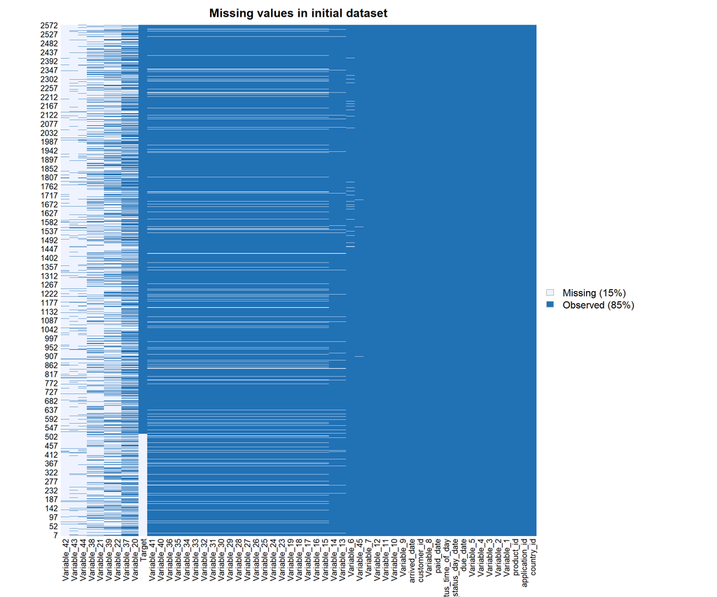

```r
### View maps of missing value
suppressWarnings(
  Amelia::missmap(DT,
                  main = 'Missing values in initial dataset'))
```

#### Primary data processing:

```r
## Find cols with all NA's
describe(DT[, .SD,
            .SDcols = names(DT)[sapply(DT,
                                       function(x) {
                                         all(is.na(x))
                                       })]])

##  Find cols with only 1 unique value
describe(DT[, .SD,
            .SDcols = names(DT)[sapply(DT,
                                       function(x) {
                                         length(unique(x)) == 1 &
                                           sum(is.na(x)) == 0
                                       })]])
### get names of cols with only value
(x.only <- names(DT)[sapply(DT,
                            function(x) {
                              length(unique(x)) == 1 &
                                sum(is.na(x)) == 0
                            })])
### del cols with only 1 unique value
DT[, c(x.only) := NULL]

##  Find cols with all unique value (like ID)
describe(DT[, .SD,
            .SDcols = names(DT)[sapply(DT,
                                       function(x) {
                                         length(unique(x)) == length(x) &
                                           sum(is.na(x)) == 0
                                       })]])
### get names of cols cols with all (not NA's & unique value)
(x.all <- names(DT)[sapply(DT,
                           function(x) {
                             length(unique(x)) == length(x) &
                               sum(is.na(x)) == 0
                           })])
### del cols with all (not NA's & unique value)
DT[, c(x.all) := NULL]

## Find fields names that's have DATE value
(x.date <- names(DT)[ sapply(DT,
                             function(x) {
                               !all(
                                 is.na(
                                   grep("^\\d{2,4}[-./]\\d{2}[-./]\\d{2,4}", x)
                                 ))})])

## Find fields names that's have TIME value
(x.time <- names(DT)[ sapply(DT,
                             function(x) {
                               !all(
                                 is.na(
                                   grep("^\\d{2}[:]\\d{2}[:]\\d{2}", x)
                                 ))})])

## Split <arrived_date> on date and time
DT[, ':='(arrived_time = substr(arrived_date, 12, 17),  # get arrived time
          arrived_date = substr(arrived_date, 1, 10)    # get arrived date
)]
x.time <- c(x.time, 'arrived_time')  # add

## Parse date\time params & add new cols with it
DT[, ':='(due_date_year  = year(dmy(due_date)),  # parse year from <due_date>
          due_date_month = month(dmy(due_date)), # parse month
          due_date_day   = day(dmy(due_date)),   # parse day of month
          due_date_wday  = wday(dmy(due_date)),  # parse day of week

          first_status_day_date_year  = year(dmy(first_status_day_date)),  # parse year
          first_status_day_date_month = month(dmy(first_status_day_date)), # parse month
          first_status_day_date_day   = day(dmy(first_status_day_date)),   # parse day of month
          first_status_day_date_wday  = wday(dmy(first_status_day_date)),  # parse day of week

          paid_date_year  = year(dmy(paid_date)),  # parse year from <paid_date>
          paid_date_month = month(dmy(paid_date)), # parse month
          paid_date_day   = day(dmy(paid_date)),   # parse day of month
          paid_date_wday  = wday(dmy(paid_date)),  # parse day of week

          arrived_date_year  = year(dmy(arrived_date)),  # parse year from <arrived_date>
          arrived_date_month = month(dmy(arrived_date)), # parse month
          arrived_date_day   = day(dmy(arrived_date)),   # parse day of month
          arrived_date_wday  = wday(dmy(arrived_date)),  # parse day of week

          Variable_42_year  = year(dmy(Variable_42)),  # parse year from <Variable_42>
          Variable_42_month = month(dmy(Variable_42)), # parse month
          Variable_42_day   = day(dmy(Variable_42)),   # parse day of month
          Variable_42_wday  = wday(dmy(Variable_42)),  # parse day of week

          Variable_43_year  = year(dmy(Variable_43)),  # parse year from <Variable_43>
          Variable_43_month = month(dmy(Variable_43)), # parse month
          Variable_43_day   = day(dmy(Variable_43)),   # parse day of month
          Variable_43_wday  = wday(dmy(Variable_43)),  # parse day of week

          Variable_44_year  = year(dmy(Variable_44)),  # parse year from <Variable_44>
          Variable_44_month = month(dmy(Variable_44)), # parse month
          Variable_44_day   = day(dmy(Variable_44)),   # parse day of month
          Variable_44_wday  = wday(dmy(Variable_44)),  # parse day of week

          first_status_time_of_day_hour  = hour(hms(first_status_time_of_day)),    # parse hour
          first_status_time_of_day_min   = minute(hms(first_status_time_of_day)),  # parse minute
          first_status_time_of_day_sec   = second(hms(first_status_time_of_day)),  # parse second

          arrived_time_hour  = hour(hm(arrived_time)),    # parse hour
          arrived_time_min   = minute(hm(arrived_time))  # parse minute
)]

### del early parsed date\time columns
DT[, c('due_date', 'first_status_day_date', 'paid_date', 'arrived_date',
       'Variable_42', 'Variable_43', 'Variable_44', 'first_status_time_of_day',
       'arrived_time') := NULL]

### coerce chars to factors
(x.char <- names(DT)[DT[, sapply(.SD, class)] == 'character'])
describe(DT[, .SD, .SDcols = DT[, sapply(.SD, class)] == 'character'])
DT[, (x.char) := lapply(.SD, as.factor), .SDcols = (x.char)]

### del useless values
rm(x.all, x.date, x.time, x.only, x.char)
```

#### Creating indexes.

Create indexes for cross-validation, training and testing models and for the set should to be predicted

```r
## create outcome vector for learning
y <- DT[, as.numeric(Target)]

## set up train and test indexs
set.seed(1414)
# row indexes of data for final prediction
idx.final.pred <- DT[is.na(Target), which = TRUE]
# row indexes of data for cross-validation and fitting final model
idx.cv <- DT[!idx.final.pred, which = TRUE]
# row indexes of data for fit model
idx.cv.train <- sort(sample(idx.cv, length(idx.cv)*.8, replace = FALSE))
# row indexes of data for test model
idx.cv.test <- idx.cv[-idx.cv.train]
```

#### Defining most important features.

With XGBoost define most important features, which explain 99%, and pickup it’s.

```r
## Create xgb matrix
xgb.impt.X <- xgb.DMatrix(as.matrix(DT[idx.cv,
                                       lapply(.SD, as.numeric),
                                       .SDcols = !c('Target')]),
                          label = y[idx.cv])

## Define params for xgboost
xgb.impt.params <- list(booster = 'gbtree',
                        eta = .05,
                        gamma = 0,
                        max_depth = 3,
                        min_child_weight = 1,
                        objective = 'binary:logistic',
                        eval_metric = 'error')

## Fit the mogel XGB
set.seed(1414)
xgb.impt.fit <- xgb.train(data = xgb.impt.X,
                          params = xgb.impt.params,
                          nrounds = 100,
                          verbose = 1,
                          print_every_n = 5,
                          watchlist = list(train = xgb.impt.X))
```

[figure not shown]

```r
## View features importantce
xgb.ggplot.importance(xgb.importance(colnames(xgb.impt.X),
                                     model = xgb.impt.fit)) +
  ggplot2::ggtitle('Target ~ All features',
                   subtitle = 'Feature importance by XGBoost') +
  ggplot2::theme(plot.title = element_text(size = 10, face = "bold"),
                 axis.text.y = element_text(size = 7.5)) +
  ggplot2::aes(width = .7)
```

```r
## Get 99% important features names
x.imp.99 <- xgb.importance(colnames(xgb.impt.X),
                            model = xgb.impt.fit)[cumsum(Gain)<=.99,
                                                  Feature]

## Make sure that the model quality does not fall on important features
### Create matrix for fit model only by important features
xgb.impt.X.99 <- xgb.DMatrix(as.matrix(DT[idx.cv,
                                          lapply(.SD, as.numeric),
                                          .SDcols = x.imp.99]),
                             label = y[idx.cv])
### fit the mogel on important features
set.seed(1414)
xgb.impt.fit.99 <- xgb.train(data = xgb.impt.X.99,
                             params = xgb.impt.params,
                             nrounds = 100,
                             verbose = 1,
                             print_every_n = 5,
                             watchlist = list(train = xgb.impt.X.99))
```

```r
### view errors
data.frame(Min_error_onAall_features =
             min(xgb.impt.fit$evaluation_log$train_error),
           Min_error_onImportant_features =
             min(xgb.impt.fit.99$evaluation_log$train_error))
```

| Min_error_onAall_features | Min_error_onImportant_features |
| --- | --- |
| 0.259601 | 0.259115 |

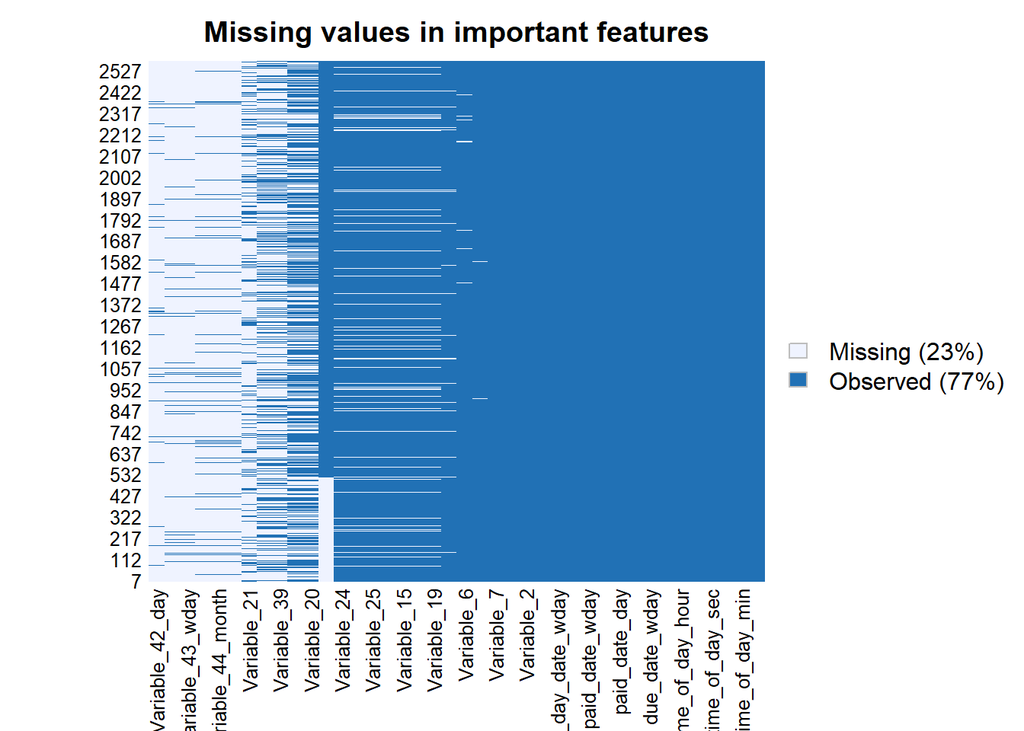

```r
## View maps of missing value in selected important features
suppressWarnings(
  Amelia::missmap(DT[, c(x.imp.99, 'Target'), with = FALSE],
                  main = 'Missing values in important features'))
```

#### Processing important features.

Delete from important features those, thats have more than 75% missing value. After, by bagging modelling, impute missing values in dataset, since some algorithms can not work with missing data.

```r
## Get names of important features that has more than 75% missing value
(x.na.75 <- colnames(DT.99)[sapply(DT.99,
                                   function(x){
                                     sum(is.na(x))/length(x) > .75})])
```

```
## [1] "Variable_44_day"   "Variable_44_month" "Variable_42_day"
## [4] "Variable_43_wday"  "Variable_44_wday"  "Variable_21"
## [7] "Variable_43_day"
```

```r
## Del thats features (x.na.75) from dataset
DT.99.75 <- DT.99[, !c(x.na.75), with = FALSE]

## Impute missing values by bagging
### coerce to numeric
DT.99.75 <- DT.99.75[, lapply(.SD, as.numeric)]
### fit imputing bagging model for missing values
pPbI <- preProcess(DT.99.75[, -c('Target'), with = FALSE],
                   method = 'bagImpute')
### predict & impute missing value
DT.99.75.imput <- predict(pPbI, DT.99.75[, -c('Target'), with = FALSE])
### view result
suppressWarnings(
  Amelia::missmap(DT.99.75.imput,
                  main = 'Missing values after bagging-imputation'))
```

[figure not shown]

#### Selection the model for final prediction.

With cross-validation, fit the different models:  
* K-nearest neighbors algorithm,  
* Logistic regression,  
* Support vector machine,  
* Extreme gradient boosting trees,  
* Naive Bayesian classifier,

on important features dataset with imputed NA’s.  
Than compare errors of these models and select a model, which be used as final for prediction.

```r
## Set training scheme for cross-validation
train.cv.ctrl <- trainControl(method = 'cv',        # method of cross-validation
                              number = 5,           # folds
                              verboseIter = TRUE,
                              allowParallel = TRUE,
                              classProbs = TRUE,
                              summaryFunction = twoClassSummary,
                              savePredictions = TRUE)

## Train KNN model
set.seed(1414)
knn.cv.fit <- train(x = DT.99.75.imput[idx.cv, ],
                    y = factor(y[idx.cv], labels = c('no', 'yes')),
                    method = 'knn',
                    preProcess = c('center', 'scale'),
                    trControl = train.cv.ctrl,
                    metric = 'ROC')

## Train the Logistic Regression model
set.seed(1414)
lg.cv.fit <- train(x = DT.99.75.imput[idx.cv, ],
                   y = factor(y[idx.cv], labels = c('no', 'yes')),
                   method = 'glm',
                   family = binomial(),
                   trControl = train.cv.ctrl,
                   metric = 'ROC')

## Train the SVM model
set.seed(1414)
svm.cv.fit <- train(x = DT.99.75.imput[idx.cv, ],
                    y = factor(y[idx.cv], labels = c('no', 'yes')),
                    method = 'svmRadial',
                    trControl = train.cv.ctrl,
                    metric = 'ROC')

## Train the xgbTree model
set.seed(1414)
xgb.cv.fit <- train(x = DT.99.75.imput[idx.cv, ],
                    y = factor(y[idx.cv], labels = c('no', 'yes')),
                    method = 'xgbTree',
                    trControl = train.cv.ctrl,
                    metric = 'ROC')

## Train the Naive Bayes model
nb.cv.fit <- train(x = DT.99.75.imput[idx.cv, ],
                   y = factor(y[idx.cv], labels = c('no', 'yes')),
                   method = 'nb',
                   trControl = train.cv.ctrl,
                   metric = 'ROC')
```

```r
## Collect resamples & view results
results.cv <- resamples(list(KNN = knn.cv.fit,
                             LogReg = lg.cv.fit,
                             SVM = svm.cv.fit,
                             XGB = xgb.cv.fit,
                             NaiveBayes = nb.cv.fit))
summary(results.cv)
```

```
##
## Call:
## summary.resamples(object = results.cv)
##
## Models: KNN, LogReg, SVM, XGB, NaiveBayes
## Number of resamples: 5
##
## ROC
##                 Min.   1st Qu.    Median      Mean   3rd Qu.      Max. NA's
## KNN        0.5617074 0.5879978 0.6226399 0.6094998 0.6314184 0.6437353    0
## LogReg     0.6345628 0.6502089 0.6556391 0.6579138 0.6597261 0.6894322    0
## SVM        0.6149819 0.6227958 0.6447229 0.6392657 0.6478795 0.6659483    0
## XGB        0.6289819 0.6562935 0.6619048 0.6665923 0.6838749 0.7019063    0
## NaiveBayes 0.5819312 0.6327393 0.6380505 0.6441931 0.6819174 0.6863269    0
##
## Sens
##                   Min.    1st Qu.     Median       Mean    3rd Qu.       Max.
## KNN        0.236220472 0.31746032 0.32539683 0.32384702 0.33858268 0.40157480
## LogReg     0.110236220 0.15748031 0.15748031 0.16440445 0.18253968 0.21428571
## SVM        0.007874016 0.03937008 0.03968254 0.05058118 0.07936508 0.08661417
## XGB        0.062992126 0.08730159 0.11023622 0.10901137 0.13492063 0.14960630
## NaiveBayes 0.755905512 0.80158730 0.81889764 0.82943382 0.88188976 0.88888889
##            NA's
## KNN           0
## LogReg        0
## SVM           0
## XGB           0
## NaiveBayes    0
##
## Spec
##                 Min.   1st Qu.    Median      Mean   3rd Qu.      Max. NA's
## KNN        0.7824561 0.7964912 0.8175439 0.8096985 0.8204225 0.8315789    0
## LogReg     0.9052632 0.9192982 0.9403509 0.9318928 0.9471831 0.9473684    0
## SVM        0.9473684 0.9649123 0.9788732 0.9754238 0.9894737 0.9964912    0
## XGB        0.9192982 0.9403509 0.9473684 0.9466321 0.9507042 0.9754386    0
## NaiveBayes 0.3204225 0.3228070 0.3403509 0.3412775 0.3543860 0.3684211    0
```

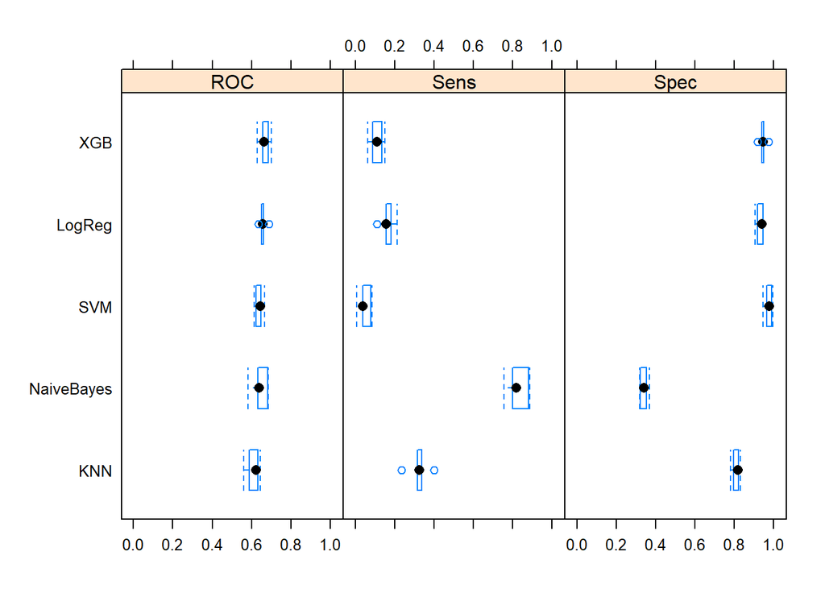

```r
bwplot(results.cv)
```

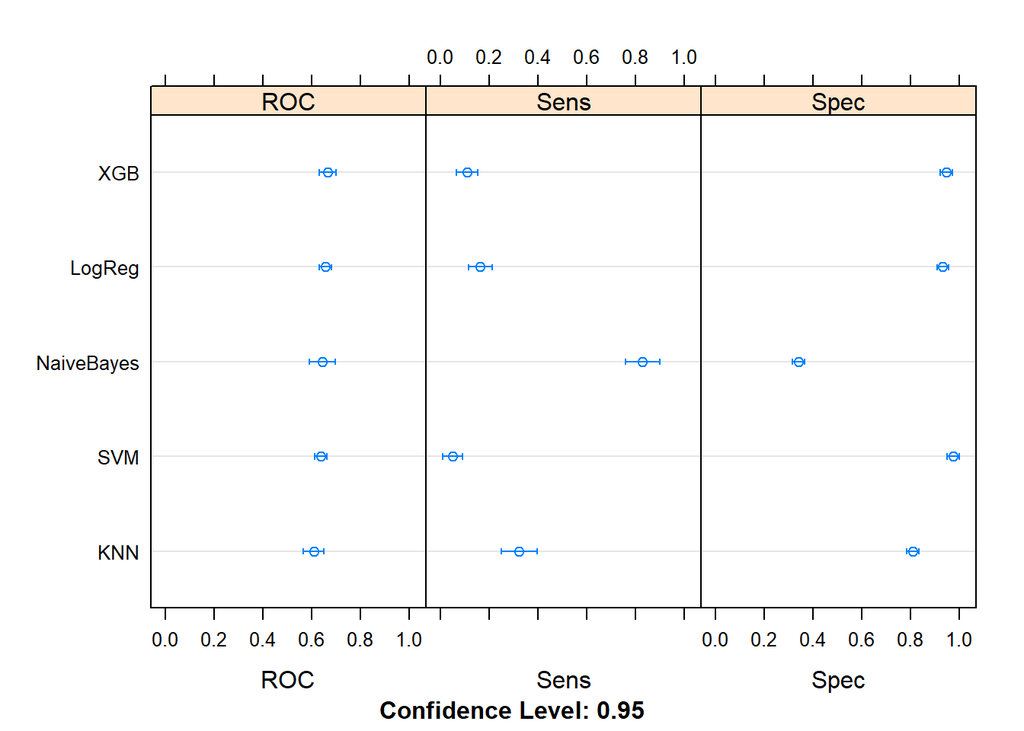

```r
dotplot(results.cv)
```

The large gap between sensitivity and specificity is probably due to some imbalance Target in the data.  
Looking at the ROC, choose the XGBtrees model. And the gap between sensitivity and specificity will later be compensated by balancing the data set.

#### Balansing data.

With SMOTE-approach (Synthetic Minority Over-sampling Technique), using over-sampling and under-sampling create new balanced dataset with important features for fitting final model.

```r
set.seed(1414)
## With SMOTE function make balance
DT.99.cv.balanced <- SMOTE(Target ~.,
                           DT.99.cv,
                           perc.over = 300,
                           perc.under = 134,
                           k = 5)
```

| Target | Original_freq | Original_count | Balanced_freq | Balanced_count |
| --- | --- | --- | --- | --- |
| 0 | 30.77297 | 633 | 49.8818 | 2532 |
| 1 | 69.22703 | 1424 | 50.1182 | 2544 |

#### Tuning hyperparams for our XGB model.

By 5-folds cross-validation fit xgb-models on balanced dataset. And then check the accuracy of prediction on using splited balanced data on train and test sets.

Find optimal hyperparametrs for model:

```r
## Params grid for tuning XGBoost hyperparams by CARET
xgb.cv.grid <- expand.grid(nrounds = seq(100, 1000, by = 300),
                           max_depth = seq(1, 7, by = 2),
                           eta =  c(.005, .01, .05, .1),
                           gamma = 0,
                           min_child_weight = c(1, 3, 5),
                           colsample_bytree = c(0.8, 1),
                           subsample = c(0.8, 1))

## Train models by CARET on CV for defining hyperparams
xgb.cv.balanced.tune <- train(x = as.matrix(
                                    DT.99.cv.balanced[ ,
                                        lapply(.SD, as.numeric),
                                        .SDcols = !c('Target')]),
                              y = factor(DT.99.cv.balanced[, Target],
                                         labels = c('no', 'yes')),
                              method = 'xgbTree',
                              trControl = train.cv.ctrl,
                              tuneGrid = xgb.cv.grid,
                              metric = 'ROC')
```

Split our balanced data, and with optimal hyperparametrs train model and view Accuracy on test set:

```r
## Set train & test indexes for balanced dataset
set.seed(1414)
idx.train.balanced <- sort(sample(seq(1, DT.99.cv.balanced[, .N]),
                                  DT.99.cv.balanced[, .N] * .8,
                                  replace = FALSE))
idx.test.balanced <- seq(1, DT.99.cv.balanced[, .N])[-idx.train.balanced]

## Create xgbMatrix for train model on balansed set and with tuned params
xgb.train.X.99.balanced <- xgb.DMatrix(
  as.matrix(DT.99.cv.balanced[idx.train.balanced,
                              lapply(.SD, as.numeric),
                              .SDcols = !c('Target')]),
  label = as.numeric(DT.99.cv.balanced[idx.train.balanced,
                                       Target])-1)
xgb.test.X.99.balanced <-  xgb.DMatrix(
  as.matrix(DT.99.cv.balanced[idx.test.balanced,
                              lapply(.SD, as.numeric),
                              .SDcols = !c('Target')]),
  label = as.numeric(DT.99.cv.balanced[idx.test.balanced,
                                       Target])-1)

## Tuned by CARET params for XGB model
xgb.train.params.balanced <- list(booster = 'gbtree',
                                  max_delta_step = 0,
                                  eta = .05,
                                  gamma = 0,
                                  max_depth = 7,
                                  min_child_weight = 1,
                                  subsample = 0.8,
                                  colsample_bytree = 1,
                                  num_parallel_tree = 1,
                                  objective = 'binary:logistic',
                                  eval_metric = 'error')

## Train the mogel with tuned params on train balanced subset
set.seed(1414)
xgb.train.X.99.balanced.fit <- xgb.train(data = xgb.train.X.99.balanced,
                                         params = xgb.train.params.balanced,
                                         nrounds = 1000,
                                         verbose = 1,
                                         print_every_n = 50,
                                         watchlist = list(train = xgb.train.X.99.balanced,
                                                          test = xgb.test.X.99.balanced))
```

```r
##  View confusion matrix on test set
confusionMatrix(
  as.factor(
    ifelse(
      predict(object = xgb.train.X.99.balanced.fit,
              newdata = xgb.test.X.99.balanced) >= .5, 1, 0)),
  as.factor(as.numeric(DT.99.cv.balanced[idx.test.balanced,
                                         Target])-1))
```

```
## Confusion Matrix and Statistics
##
##           Reference
## Prediction   0   1
##          0 411  28
##          1  75 502
##
##                Accuracy : 0.8986
##                  95% CI : (0.8784, 0.9165)
##     No Information Rate : 0.5217
##     P-Value [Acc > NIR] : < 2.2e-16
##
##                   Kappa : 0.796
##
##  Mcnemar's Test P-Value : 5.829e-06
##
##             Sensitivity : 0.8457
##             Specificity : 0.9472
##          Pos Pred Value : 0.9362
##          Neg Pred Value : 0.8700
##              Prevalence : 0.4783
##          Detection Rate : 0.4045
##    Detection Prevalence : 0.4321
##       Balanced Accuracy : 0.8964
##
##        'Positive' Class : 0
##
```

The accuracy indicator looks good. In addition, the gap between the sensitivity and specificity disappeared.

#### Final.

Train final tuned model.

```r
## Create xgbMatrix for train final model
xgb.X.99.final.balanced <- xgb.DMatrix(
  as.matrix(DT.99.cv.balanced[ ,
                               lapply(.SD, as.numeric),
                               .SDcols = !c('Target')]),
  label = as.numeric(DT.99.cv.balanced[ ,
                                        Target])-1)

## Train the final mogel with tuned params on final train set
set.seed(1414)
xgb.final.balanced.fit <- xgb.train(data = xgb.X.99.final.balanced,
                                    params = xgb.train.params.balanced,
                                    nrounds = 1000,
                                    verbose = 1,
                                    print_every_n = 50,
                                    watchlist = list(train = xgb.X.99.final.balanced))
```

Make prediction.

```r
## FINAL PREDICTION
### Create xgb Matrix witn unknown data for prediction
xgb.X.final.pred <- xgb.DMatrix(
  as.matrix(DT.99.final.pred[ ,
                            lapply(.SD, as.numeric),
                            .SDcols = !c('Target')]),
  label = as.numeric(DT.99.final.pred[ ,
                                      Target])-1)
### PREDICTION
prob.final.pred <- as.numeric(
  predict(object = xgb.final.balanced.fit,
          newdata = xgb.X.final.pred))
```

| Target | Original_freq | Original_count | Predicted_freq | Predicted_count |
| --- | --- | --- | --- | --- |
| 0 | 30.77297 | 633 | 28.93204 | 149 |
| 1 | 69.22703 | 1424 | 71.06796 | 366 |

The distribution of the predicted values looks similar to the known values in the original data set.

```r
## SAVE PREDICTED PROBABILITY VECTOR
fwrite(as.list(prob.final.pred), 'GalkinM_Predicted.csv', sep = ';')
```